# Assignment 2

DATA311 - Machine Learning

Author

Rin Meng, 51940633

# Exploratory / Pre-Processing

### Exercise 1

a. Classification  
d. Supervised

### Exercise 2 (Data Preparing and Summary)

```r
telco <- read.table(("telcochurn.csv"), header=TRUE, sep = ",")
telco <- na.omit(telco)
# Make sure its factored into levels Yes and No
telco$Churn <- as.factor(telco$Churn)
telco$tenure <- as.numeric(telco$tenure)
telco$gender <- as.factor(telco$gender)
telco$SeniorCitizen <- as.factor(telco$SeniorCitizen)
telco$Partner <- as.factor(telco$Partner)
telco$Dependents <- as.factor(telco$Dependents)
telco$PhoneService <- as.factor(telco$PhoneService)
telco$MultipleLines <- as.factor(telco$MultipleLines)
telco$InternetService <- as.factor(telco$InternetService)
telco$OnlineSecurity <- as.factor(telco$OnlineSecurity)
telco$OnlineBackup <- as.factor(telco$OnlineBackup)
telco$DeviceProtection <- as.factor(telco$DeviceProtection)
telco$TechSupport <- as.factor(telco$TechSupport)
telco$StreamingTV <- as.factor(telco$StreamingTV)
telco$StreamingMovies <- as.factor(telco$StreamingMovies)
telco$Contract <- as.factor(telco$Contract)
telco$PaperlessBilling <- as.factor(telco$PaperlessBilling)
telco$PaymentMethod <- as.factor(telco$PaymentMethod)
telco$MonthlyCharges <- as.numeric(telco$MonthlyCharges)
telco$TotalCharges <- as.numeric(telco$TotalCharges)
str(telco)
```

```
'data.frame':   7032 obs. of  21 variables:
 $ customerID      : chr  "7590-VHVEG" "5575-GNVDE" "3668-QPYBK" "7795-CFOCW" ...
 $ gender          : Factor w/ 2 levels "Female","Male": 1 2 2 2 1 1 2 1 1 2 ...
 $ SeniorCitizen   : Factor w/ 2 levels "0","1": 1 1 1 1 1 1 1 1 1 1 ...
 $ Partner         : Factor w/ 2 levels "No","Yes": 2 1 1 1 1 1 1 1 2 1 ...
 $ Dependents      : Factor w/ 2 levels "No","Yes": 1 1 1 1 1 1 2 1 1 2 ...
 $ tenure          : num  1 34 2 45 2 8 22 10 28 62 ...
 $ PhoneService    : Factor w/ 2 levels "No","Yes": 1 2 2 1 2 2 2 1 2 2 ...
 $ MultipleLines   : Factor w/ 3 levels "No","No phone service",..: 2 1 1 2 1 3 3 2 3 1 ...
 $ InternetService : Factor w/ 3 levels "DSL","Fiber optic",..: 1 1 1 1 2 2 2 1 2 1 ...
 $ OnlineSecurity  : Factor w/ 3 levels "No","No internet service",..: 1 3 3 3 1 1 1 3 1 3 ...
 $ OnlineBackup    : Factor w/ 3 levels "No","No internet service",..: 3 1 3 1 1 1 3 1 1 3 ...
 $ DeviceProtection: Factor w/ 3 levels "No","No internet service",..: 1 3 1 3 1 3 1 1 3 1 ...
 $ TechSupport     : Factor w/ 3 levels "No","No internet service",..: 1 1 1 3 1 1 1 1 3 1 ...
 $ StreamingTV     : Factor w/ 3 levels "No","No internet service",..: 1 1 1 1 1 3 3 1 3 1 ...
 $ StreamingMovies : Factor w/ 3 levels "No","No internet service",..: 1 1 1 1 1 3 1 1 3 1 ...
 $ Contract        : Factor w/ 3 levels "Month-to-month",..: 1 2 1 2 1 1 1 1 1 2 ...
 $ PaperlessBilling: Factor w/ 2 levels "No","Yes": 2 1 2 1 2 2 2 1 2 1 ...
 $ PaymentMethod   : Factor w/ 4 levels "Bank transfer (automatic)",..: 3 4 4 1 3 3 2 4 3 1 ...
 $ MonthlyCharges  : num  29.9 57 53.9 42.3 70.7 ...
 $ TotalCharges    : num  29.9 1889.5 108.2 1840.8 151.7 ...
 $ Churn           : Factor w/ 2 levels "No","Yes": 1 1 2 1 2 2 1 1 2 1 ...
 - attr(*, "na.action")= 'omit' Named int [1:11] 489 754 937 1083 1341 3332 3827 4381 5219 6671 ...
  ..- attr(*, "names")= chr [1:11] "489" "754" "937" "1083" ...
```

### Exercise 3 (Distribution of Churn Rates)

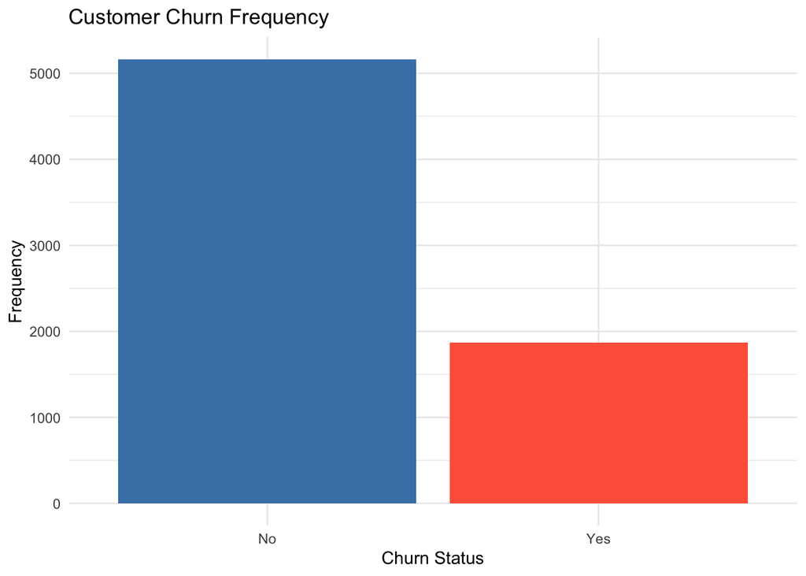

```r
library(ggplot2)

ggplot(telco, aes(x = Churn)) +
  geom_bar(fill = c("steelblue", "tomato")) +
  labs(title = "Customer Churn Frequency",
       x = "Churn Status",
       y = "Frequency") +
  theme_minimal()
```

### Exercise 4 (Data Visualization for Categorical Variables)

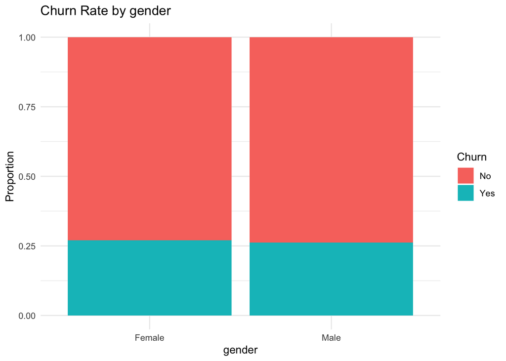

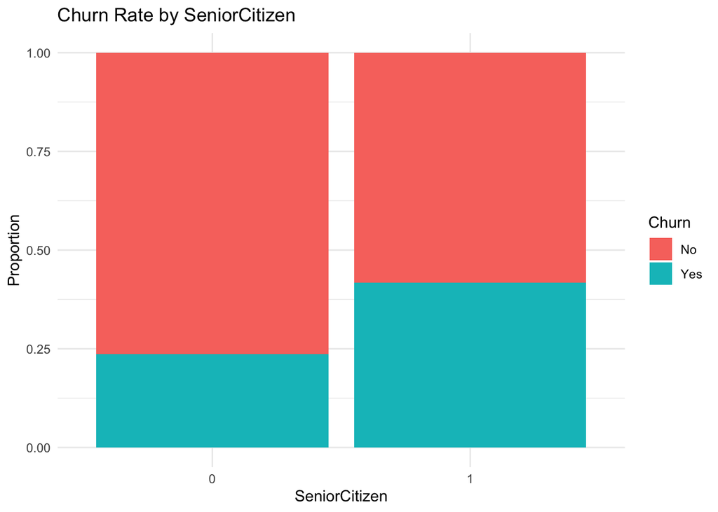

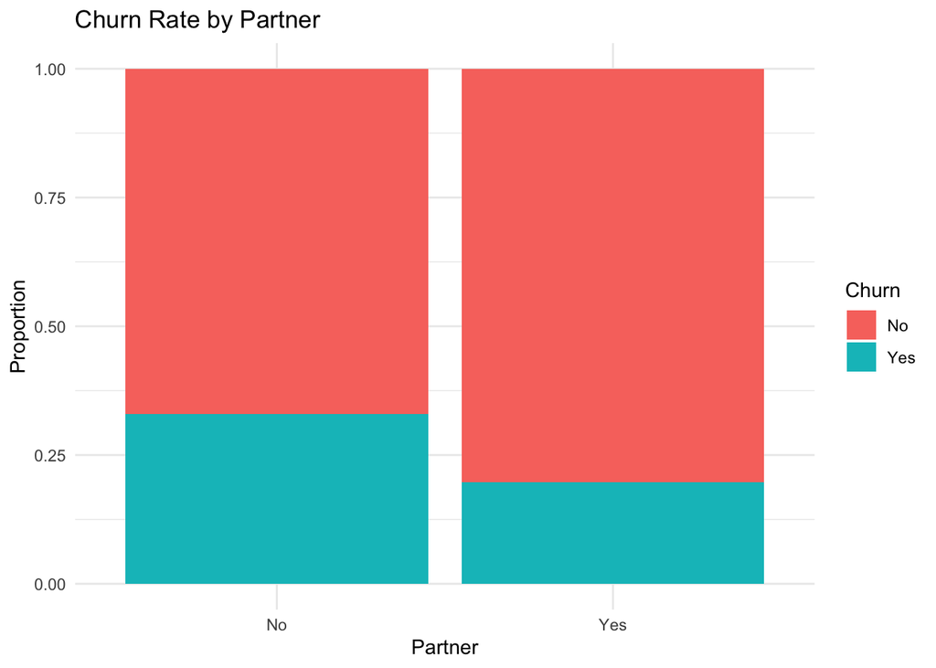

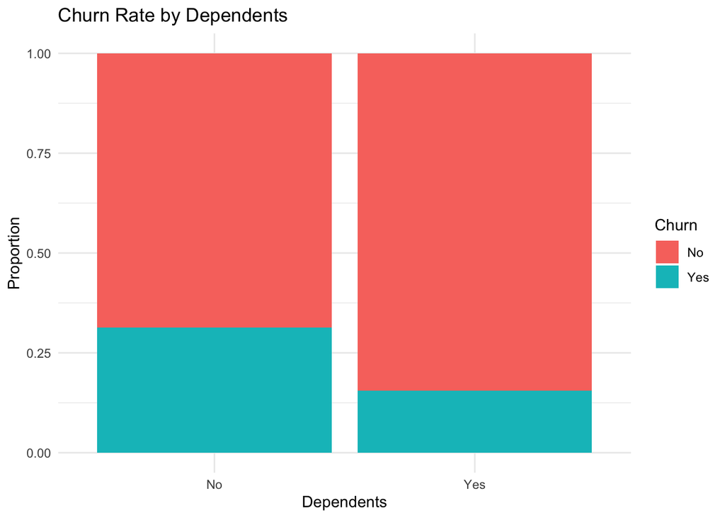

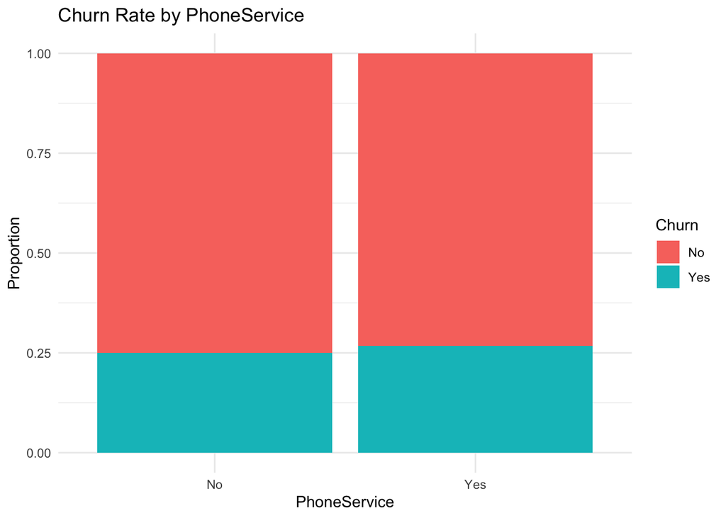

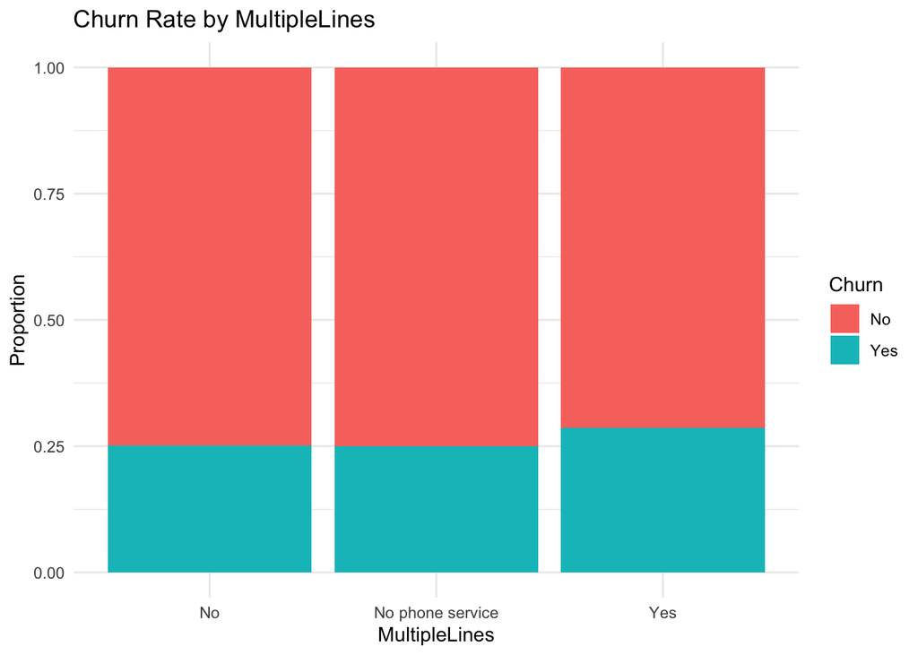

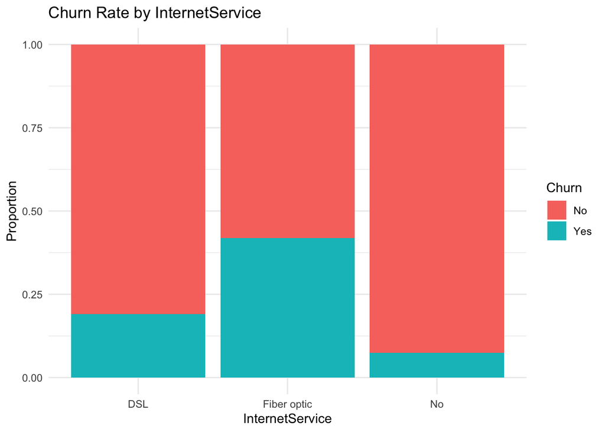

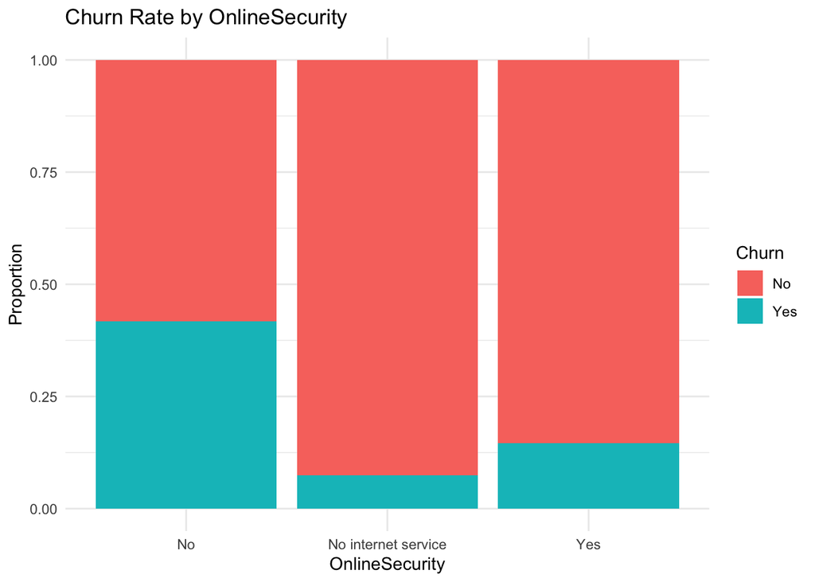

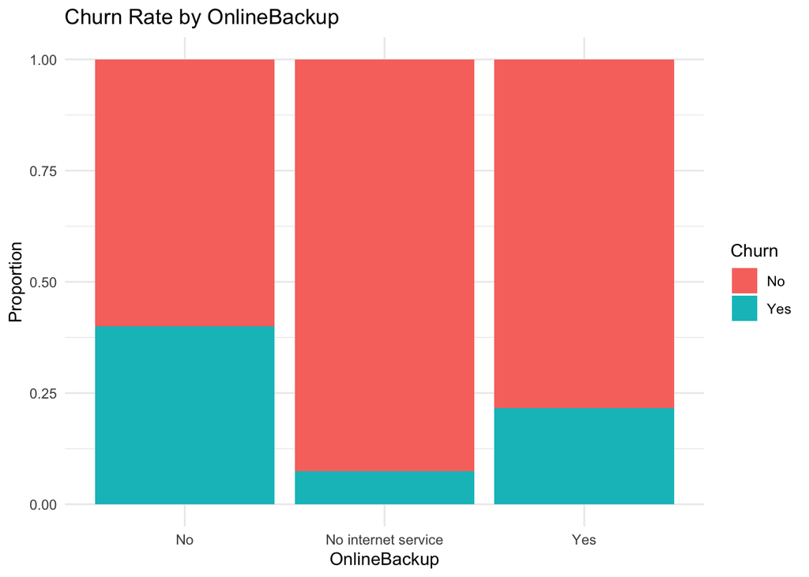

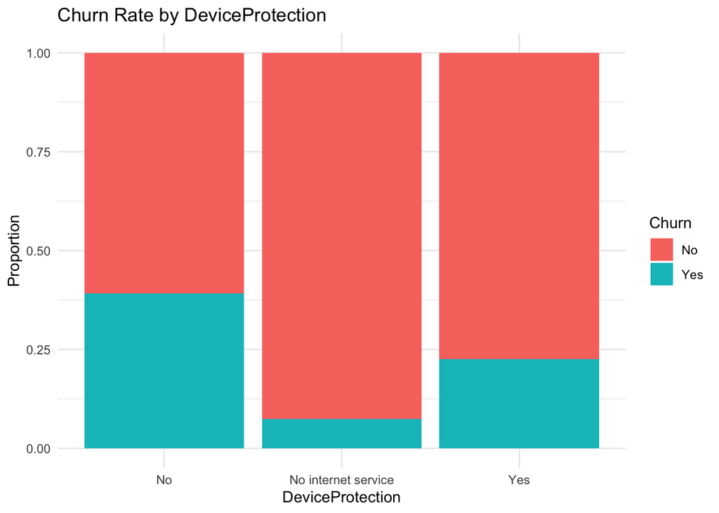

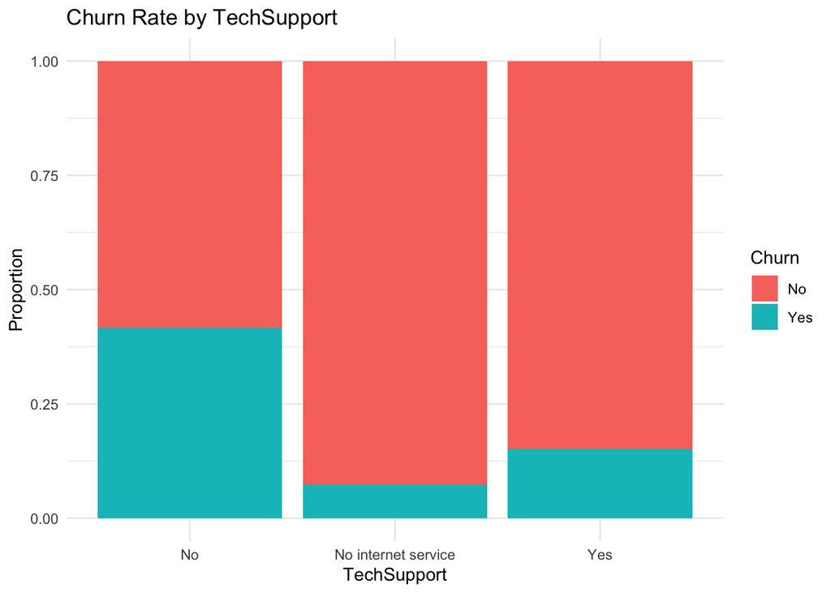

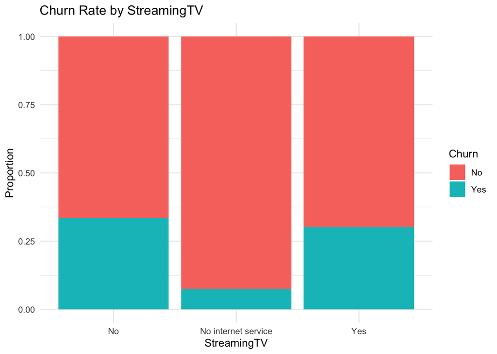

[4 more figures not shown]

```r
churnPlot <- function(predictor) {
  ggplot(telco, aes_string(x = predictor, fill = "Churn")) +  # Use aes_string for dynamic x aesthetic
    geom_bar(position = "fill") +
    labs(title = paste("Churn Rate by", predictor), x = predictor, y = "Proportion") +  # Make title dynamic
    theme_minimal()
}

# Identify categorical predictors
predictors <- colnames(telco)
exclude_columns <- c("customerID","Churn", "MonthlyCharges", "TotalCharges","tenure","tenure_bins","TotalCharges_bins","MonthlyCharges_bin")
predictors <- predictors[!predictors %in% exclude_columns]


for (predictor in predictors) {
  print(churnPlot(predictor))
}
```

### Exercise 5 (Data Visualization for Continuous Variables)

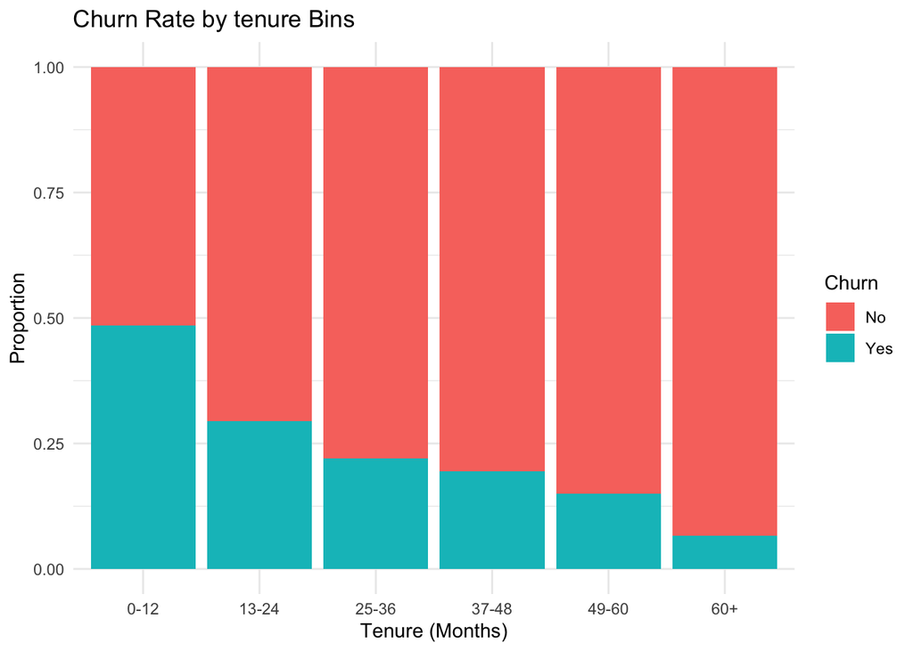

```r
# Create binned tenure categories
telco$tenure_bins <- cut(telco$tenure,
                         breaks = c(0, 12, 24, 36, 48, 60, Inf),
                         labels = c("0-12", "13-24", "25-36", "37-48", "49-60", "60+"),
                         right = FALSE,   # Include the lower bound, exclude the upper
                         include.lowest = TRUE)  # Include the lowest value
ggplot(telco, aes(x = tenure_bins, fill = Churn)) +
    geom_bar(position = "fill") +
    labs(title = "Churn Rate by tenure Bins", x = "Tenure (Months)", y = "Proportion") +
    theme_minimal()
```

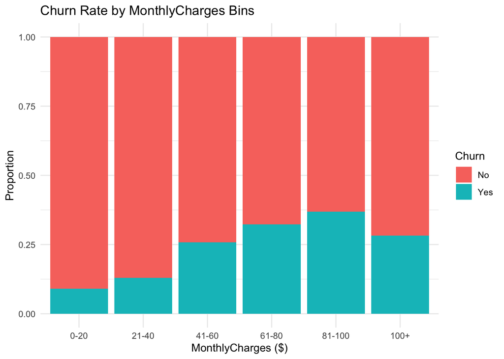

```r
telco$MonthlyCharges_bins <- cut(telco$MonthlyCharges,
                         breaks = c(0, 20, 40, 60, 80, 100, Inf),
                         labels = c("0-20", "21-40", "41-60", "61-80", "81-100", "100+"),
                         right = FALSE,   # Include the lower bound, exclude the upper
                         include.lowest = TRUE)  # Include the lowest value
ggplot(telco, aes(x = MonthlyCharges_bins, fill = Churn)) +
    geom_bar(position = "fill") +
    labs(title = "Churn Rate by MonthlyCharges Bins", x = "MonthlyCharges ($)", y = "Proportion") +
    theme_minimal()
```

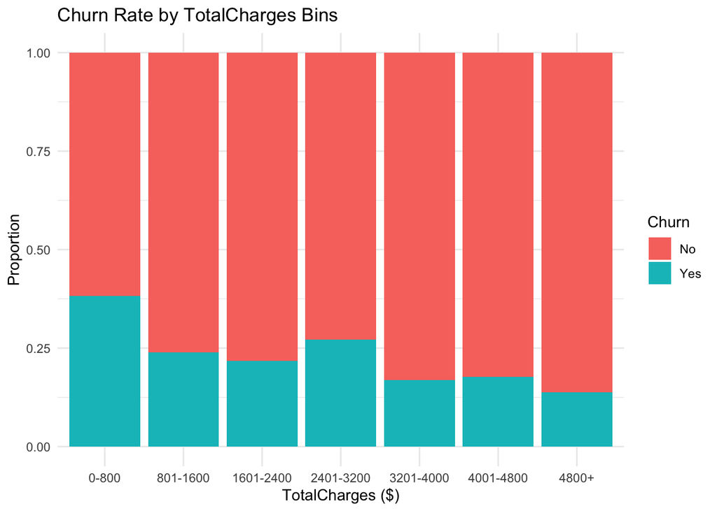

```r
telco$TotalCharges_bins <- cut(telco$TotalCharges,
                         breaks = c(0, 800, 1600, 2400, 3200, 4000, 4800, Inf),
                         labels = c("0-800", "801-1600", "1601-2400", "2401-3200", "3201-4000", "4001-4800", "4800+"),
                         right = FALSE,   # Include the lower bound, exclude the upper
                         include.lowest = TRUE)  # Include the lowest value
ggplot(telco, aes(x = TotalCharges_bins, fill = Churn)) +
    geom_bar(position = "fill") +
    labs(title = "Churn Rate by TotalCharges Bins", x = "TotalCharges ($)", y = "Proportion") +
    theme_minimal()
```

Based on these plots, the continuous variable that seems to be associated with the customer churn would be; tenure, MontlyCharges, and TotalCharges.

### Exercise 6 (Data Splitting)

```r
set.seed(51940633)
# First split: 70% training and 30% test
sampleSize <- floor(0.7 * nrow(telco))
set <- sample(seq_len(nrow(telco)), size = sampleSize)

telcoTrain <- telco[set, ]
telcoTest <- telco[-set, ]

paste("telcoTrain has", nrow(telcoTrain), "rows which is", sprintf("%.2f",100 * nrow(telcoTrain)/nrow(telco)), "% of the dataset")
```

```
[1] "telcoTrain has 4922 rows which is 69.99 % of the dataset"
```

```r
paste("telcoTest has", nrow(telcoTest), "rows which is", sprintf("%.2f",100 * nrow(telcoTest)/nrow(telco)), "% of the dataset")
```

```
[1] "telcoTest has 2110 rows which is 30.01 % of the dataset"
```

# Model Fitting

### Exercise 7 (Logistic Regression)

```r
set.seed(51940633)
telcoTrain.glm <- glm(Churn ~ tenure + MonthlyCharges + TotalCharges, data=telcoTrain, family= binomial)

summary(telcoTrain.glm)
```

```
Call:
glm(formula = Churn ~ tenure + MonthlyCharges + TotalCharges,
    family = binomial, data = telcoTrain)

Coefficients:
                 Estimate Std. Error z value Pr(>|z|)
(Intercept)    -1.6363893  0.1421280 -11.513   <2e-16 ***
tenure         -0.0645466  0.0064116 -10.067   <2e-16 ***
MonthlyCharges  0.0305762  0.0020743  14.741   <2e-16 ***
TotalCharges    0.0001249  0.0000724   1.725   0.0846 .
---
Signif. codes:  0 '***' 0.001 '**' 0.01 '*' 0.05 '.' 0.1 ' ' 1

(Dispersion parameter for binomial family taken to be 1)

    Null deviance: 5699.5  on 4921  degrees of freedom
Residual deviance: 4486.0  on 4918  degrees of freedom
AIC: 4494

Number of Fisher Scoring iterations: 6
```

### Exercise 8 (Interpret coefficients)

1. tenure: -0.0645466
   - Interpretation: For each added month of tenure, the odds of customer churning decreases by 0.0645466. So that means that if the customer stays with the company longer, the likelihood of them churning decreases. Also implying that customer might feel like they don’t want to churn because they are satisfied with their offers/plans.
2. MonthlyCharges: 0.0305762
   - Interpretation: For each additional dollar that the company charges per month, the odds of customer churning increases by 0.0305762. So that means if the customer gets charged more per month, they are more likely to churn. Also implying that customer may be unsatisfied with the given offers/plans from the company.
3. TotalCharges: 0.0001249
   - Interpretation: For each extra dollar that the company makes from the customer, the odds of customer churning is 0.0001249 more. So that means if the customer’s total charge increases, the more likely that the customer will churn. This predictor isn’t as significant as the other two, but it can suggest that the customer that spends more total money on the company are more likely to churn.

### Exercise 9 (Your Logistic Regression)

```r
set.seed(51940633)
# Now we use those predictors that is significant
telcoTrain.glm9 <- glm(Churn ~ SeniorCitizen + tenure * Contract +
                          PaymentMethod + PaperlessBilling +
                         OnlineSecurity + TechSupport + StreamingMovies +
                         InternetService + MonthlyCharges + TotalCharges,
                       data=telcoTrain, family=binomial)
summary(telcoTrain.glm9)
```

```
Call:
glm(formula = Churn ~ SeniorCitizen + tenure * Contract + PaymentMethod +
    PaperlessBilling + OnlineSecurity + TechSupport + StreamingMovies +
    InternetService + MonthlyCharges + TotalCharges, family = binomial,
    data = telcoTrain)

Coefficients: (3 not defined because of singularities)
                                       Estimate Std. Error z value Pr(>|z|)
(Intercept)                          -2.934e-01  2.878e-01  -1.020 0.307910
SeniorCitizen1                        3.663e-01  9.854e-02   3.718 0.000201 ***
tenure                               -5.556e-02  7.050e-03  -7.880 3.27e-15 ***
ContractOne year                     -1.146e+00  2.652e-01  -4.321 1.55e-05 ***
ContractTwo year                     -3.176e+00  8.108e-01  -3.917 8.97e-05 ***
PaymentMethodCredit card (automatic) -7.356e-02  1.343e-01  -0.548 0.584008
PaymentMethodElectronic check         3.504e-01  1.117e-01   3.138 0.001704 **
PaymentMethodMailed check            -9.340e-02  1.374e-01  -0.680 0.496567
PaperlessBillingYes                   3.786e-01  8.811e-02   4.297 1.73e-05 ***
OnlineSecurityNo internet service    -9.134e-01  1.985e-01  -4.602 4.18e-06 ***
OnlineSecurityYes                    -4.123e-01  1.032e-01  -3.994 6.51e-05 ***
TechSupportNo internet service               NA         NA      NA       NA
TechSupportYes                       -4.847e-01  1.064e-01  -4.555 5.25e-06 ***
StreamingMoviesNo internet service           NA         NA      NA       NA
StreamingMoviesYes                    2.864e-01  1.122e-01   2.554 0.010663 *
InternetServiceFiber optic            6.641e-01  1.938e-01   3.426 0.000612 ***
InternetServiceNo                            NA         NA      NA       NA
MonthlyCharges                       -9.173e-04  5.393e-03  -0.170 0.864922
TotalCharges                          2.509e-04  8.312e-05   3.018 0.002542 **
tenure:ContractOne year               1.496e-02  6.007e-03   2.491 0.012738 *
tenure:ContractTwo year               3.337e-02  1.304e-02   2.559 0.010502 *
---
Signif. codes:  0 '***' 0.001 '**' 0.01 '*' 0.05 '.' 0.1 ' ' 1

(Dispersion parameter for binomial family taken to be 1)

    Null deviance: 5699.5  on 4921  degrees of freedom
Residual deviance: 4099.5  on 4904  degrees of freedom
AIC: 4135.5

Number of Fisher Scoring iterations: 6
```

### Exercise 10 (K-Nearest Neighbors Classification)

```r
library(caret)
library(dplyr)
set.seed(51940633)

# Define the training control for cross-validation
control_10fold <- trainControl(method = "cv", number = 10)

# Train KNN model
# Specify a grid of k values (for example, from 1 to 50)
k_values <- data.frame(k = seq(1, 50, by = 1))

knn_model <- train(Churn ~ SeniorCitizen + tenure + Contract +
                          PaymentMethod + PaperlessBilling +
                         OnlineSecurity + TechSupport + StreamingMovies +
                         InternetService + MonthlyCharges + TotalCharges,
                       data=telcoTrain,
                   method = "knn",
                   trControl = control_10fold,
                   tuneGrid = k_values)

# Display the results
print(knn_model)
```

```
k-Nearest Neighbors

4922 samples
  11 predictor
   2 classes: 'No', 'Yes'

No pre-processing
Resampling: Cross-Validated (10 fold)
Summary of sample sizes: 4429, 4430, 4430, 4431, 4430, 4431, ...
Resampling results across tuning parameters:

  k   Accuracy   Kappa
   1  0.7159550  0.2729968
   2  0.7171964  0.2718971
   3  0.7566071  0.3435529
```

[output cut: 50 more lines]

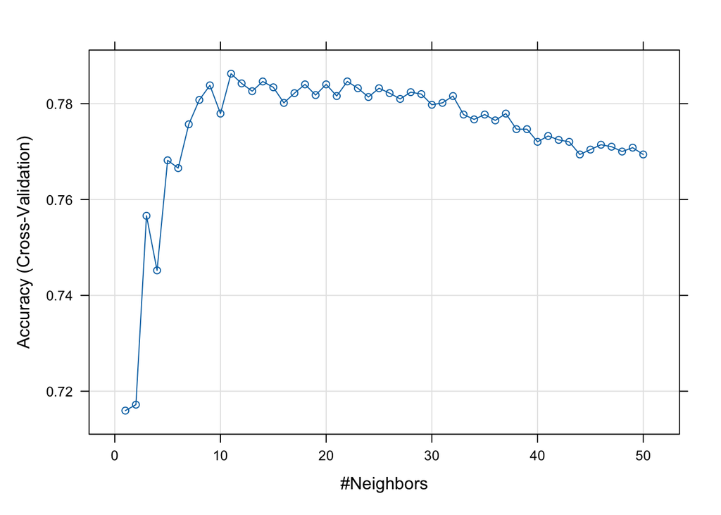

```r
plot(knn_model)
```

As per the accuracy value above, the optimal model uses k = 11.

### Exercise 11 (Retrain KNN)

```r
library(caret)
library(dplyr)
set.seed(51940633)
control_10fold <- trainControl(method = "cv", number = 10)

optimal_k <- data.frame(k = knn_model$bestTune$k)

knn_model_optimal <- train(Churn ~ SeniorCitizen + tenure + Contract +
                                 PaymentMethod + PaperlessBilling +
                                 OnlineSecurity + TechSupport + StreamingMovies +
                                 InternetService + MonthlyCharges + TotalCharges,
                          data = telcoTrain,
                          method = "knn",
                          trControl = control_10fold,
                          tuneGrid = optimal_k)

print(knn_model_optimal)
```

```
k-Nearest Neighbors

4922 samples
  11 predictor
   2 classes: 'No', 'Yes'

No pre-processing
Resampling: Cross-Validated (10 fold)
Summary of sample sizes: 4429, 4430, 4430, 4431, 4430, 4431, ...
Resampling results:

  Accuracy   Kappa
  0.7860589  0.383796

Tuning parameter 'k' was held constant at a value of 11
```

### Exercise 12 (Seeds for KNN)

The non-deterministic of the algorithm is that it that when we apply techniques like k-fold cross validation, the data is randomly split. Which means the data and outcome will vary slightly each run due to the randomness, which can lead to different performance in accuracy.

### Exercise 13 (Linear Discriminant Analysis (LDA))

```r
library(MASS)
lda_model <- lda(Churn ~ tenure + TotalCharges, data = telcoTrain)
print(lda_model)
```

```
Call:
lda(Churn ~ tenure + TotalCharges, data = telcoTrain)

Prior probabilities of groups:
       No       Yes
0.7342544 0.2657456

Group means:
      tenure TotalCharges
No  37.60653     2558.835
Yes 18.40061     1565.956

Coefficients of linear discriminants:
                       LD1
tenure       -0.0686797978
TotalCharges  0.0003725357
```

### Exercise 14 (Quadratic Discriminant Analysis)

```r
library(MASS)

qda_model <- qda(Churn ~ tenure + TotalCharges, data = telcoTrain)
print(qda_model)
```

```
Call:
qda(Churn ~ tenure + TotalCharges, data = telcoTrain)

Prior probabilities of groups:
       No       Yes
0.7342544 0.2657456

Group means:
      tenure TotalCharges
No  37.60653     2558.835
Yes 18.40061     1565.956
```

### Exercise 15 (Confusion Matrices)

```r
# Exercise 7
logistic_pred_q7 <- predict(telcoTrain.glm, newdata = telcoTest, type = "response")
logistic_pred_class_q7 <- ifelse(logistic_pred_q7 > 0.5, "Yes", "No")
logistic_conf_matrix_q7 <- confusionMatrix(factor(logistic_pred_class_q7), telcoTest$Churn)
print(logistic_conf_matrix_q7$table)
```

```
          Reference
Prediction   No  Yes
       No  1403  307
       Yes  146  254
```

```r
# Exercise 9
logistic_pred_q9 <- predict(telcoTrain.glm9, newdata = telcoTest, type = "response")
logistic_pred_class_q9 <- ifelse(logistic_pred_q9 > 0.5, "Yes", "No")
logistic_conf_matrix_q9 <- confusionMatrix(factor(logistic_pred_class_q9), telcoTest$Churn)
print(logistic_conf_matrix_q9$table)
```

```
          Reference
Prediction   No  Yes
       No  1385  250
       Yes  164  311
```

```r
# Exercise 11
knn_pred_optimal <- predict(knn_model_optimal, newdata = telcoTest)
knn_conf_matrix_optimal <- confusionMatrix(knn_pred_optimal, telcoTest$Churn)
print(knn_conf_matrix_optimal$table)
```

```
          Reference
Prediction   No  Yes
       No  1412  313
       Yes  137  248
```

```r
# Exercise 13
lda_pred <- predict(lda_model, newdata = telcoTest)
lda_conf_matrix <- confusionMatrix(lda_pred$class, telcoTest$Churn)
print(lda_conf_matrix$table)
```

```
          Reference
Prediction   No  Yes
       No  1468  410
       Yes   81  151
```

```r
# Exercise 14
qda_pred <- predict(qda_model, newdata = telcoTest)
qda_conf_matrix <- confusionMatrix(qda_pred$class, telcoTest$Churn)
print(qda_conf_matrix$table)
```

```
          Reference
Prediction   No  Yes
       No  1065  141
       Yes  484  420
```

### Exercise 16 (Model Comparison)

The recall/true positive rate formula is given by

$$\text{Recall} = \frac{\text{True Positive}}{\text{True Positive} + \text{False Negatives}}$$

$$= \frac{\text{Prediction: Yes, Reference: Yes}}{(\text{Prediction: Yes, Reference: Yes}) + (\text{Prediction: No, Reference: Yes})}$$

[output not shown]

Overall, we can clearly see that the QDA model is the winner here, giving us 74.87% accuracy of customer who churned.

### Exercise 17 (Bootstrapping for Uncertainty)

```r
# Load necessary libraries
library(boot)
library(MASS)  # For QDA model

# Create a function to calculate the statistic of interest
recall_stats <- function(data, indices) {
  sample_data <- data[indices, ]  # Create bootstrap sample

  # Fit QDA model using the formula above
  fit <- qda(Churn ~ tenure + TotalCharges, data = sample_data)

  # Predict on the resampled data
  predictions <- predict(fit, sample_data)$class

  # Calculate recall
  true_positives <- sum(predictions == "Yes" & sample_data$Churn == "Yes")
  total_actual_positives <- sum(sample_data$Churn == "Yes")
  recall <- true_positives / total_actual_positives

  return(recall)
}

# Number of bootstrap samples
B <- 1000

# Set a seed for reproducibility
set.seed(6663492)

# Perform bootstrapping
boot_recall_results <- boot(data = telcoTrain, statistic = recall_stats, R = B)

# View the results
print(boot_recall_results)
```

```
ORDINARY NONPARAMETRIC BOOTSTRAP


Call:
boot(data = telcoTrain, statistic = recall_stats, R = B)


Bootstrap Statistics :
     original       bias    std. error
t1* 0.7148318 -0.001189979   0.0157154
```

```r
# Calculate the 95% confidence interval
ci_95 <- boot.ci(boot_recall_results, type = "perc")
print(ci_95)
```

```
BOOTSTRAP CONFIDENCE INTERVAL CALCULATIONS
Based on 1000 bootstrap replicates

CALL :
boot.ci(boot.out = boot_recall_results, type = "perc")

Intervals :
Level     Percentile
95%   ( 0.6799,  0.7429 )
Calculations and Intervals on Original Scale
```

The original value at 0.7148318 implies that our QDA model correctly identifies 71.5% of all customer who churned, and the bias of -0.0012 implies that our bootstrapping recall is very close towards the original recall.

Our 95% confidence interval tells us that, our accuracy of identifying customer who churns can very between 68% and 74% with a different data.